# Лабораторная работа №10

Задача об обедающих мудрецах

Шубнякова Дарья НКНбд-01-22

1132226452@pfur.ru

Российский университет дружбы народов

# Вводная часть

## Цели и задачи

Ознакомиться с задачей об обедающих мудрецах и реализовать модель в CPNTools.

Вычислить пространство состояний. Сформировать отчёт о пространстве состояний и проанализировать его. Построить граф пространства состояний.

# Основная часть

## Выполнение лабораторной работы

### Рисуем граф сети. Для этого с помощью контекстного меню создаём новую сеть, добавляем позиции, переходы и дуги (рис. 10.1).

Начальные данные: – позиции: мудрец размышляет (philosopher thinks), мудрец ест (philosopher eats), палочки находятся на столе (sticks on the table) – переходы: взять палочки (take sticks), положить палочки (put sticks).

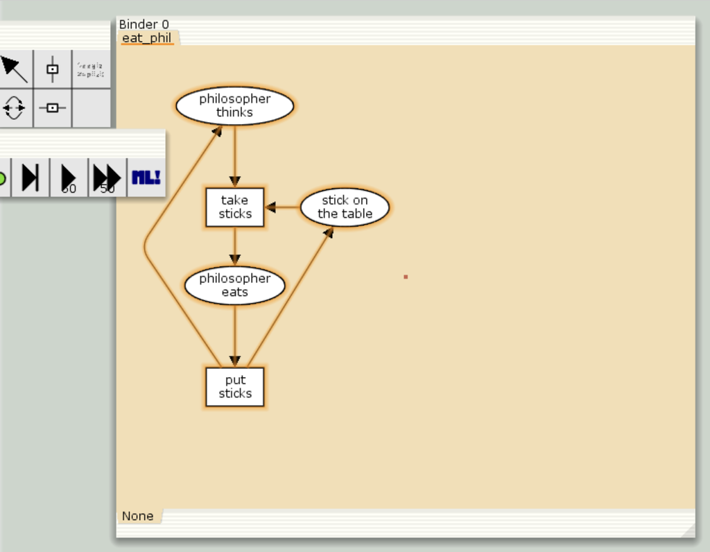

## В меню задаём новые декларации модели: типы фишек, начальные значения позиций, выражения для дуг

### – n — число мудрецов и палочек (n = 5);

– p — фишки, обозначающие мудрецов, имеют перечисляемый тип PH от 1 до n; – s — фишки, обозначающие палочки, имеют перечисляемый тип ST от 1 до n; – функция ChangeS(p) ставит в соответствие мудрецам палочки (возвращает но- мера палочек, используемых мудрецами).

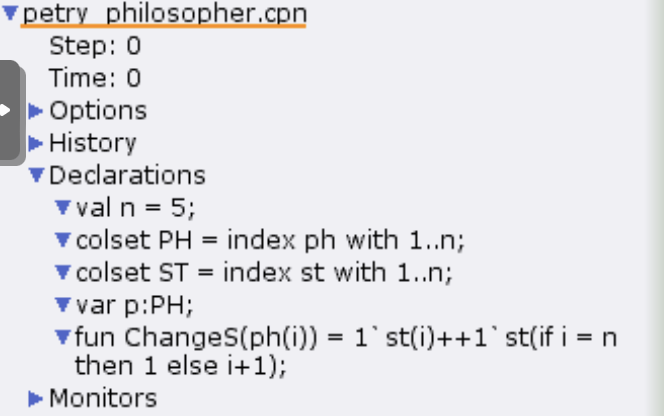

## Расставляем оставшиеся данные для функционирования модели.

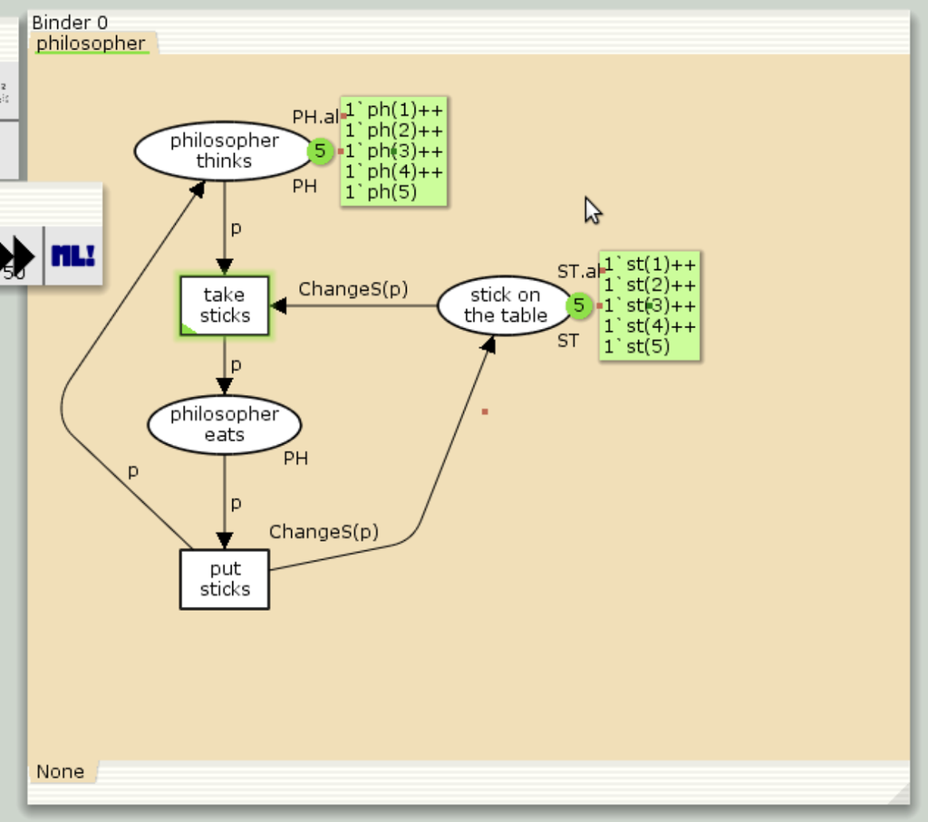

## В результате получаем работающую модель. После запуска модели наблюдаем, что одновременно палочками могут воспользоваться только два из пяти мудрецов.

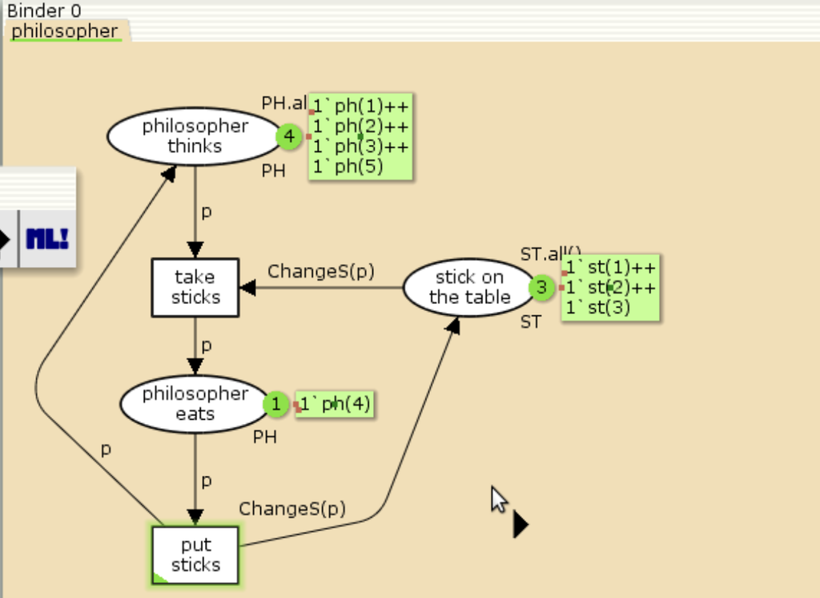

## Выполняем упражнение. Строим граф пространства состояний.

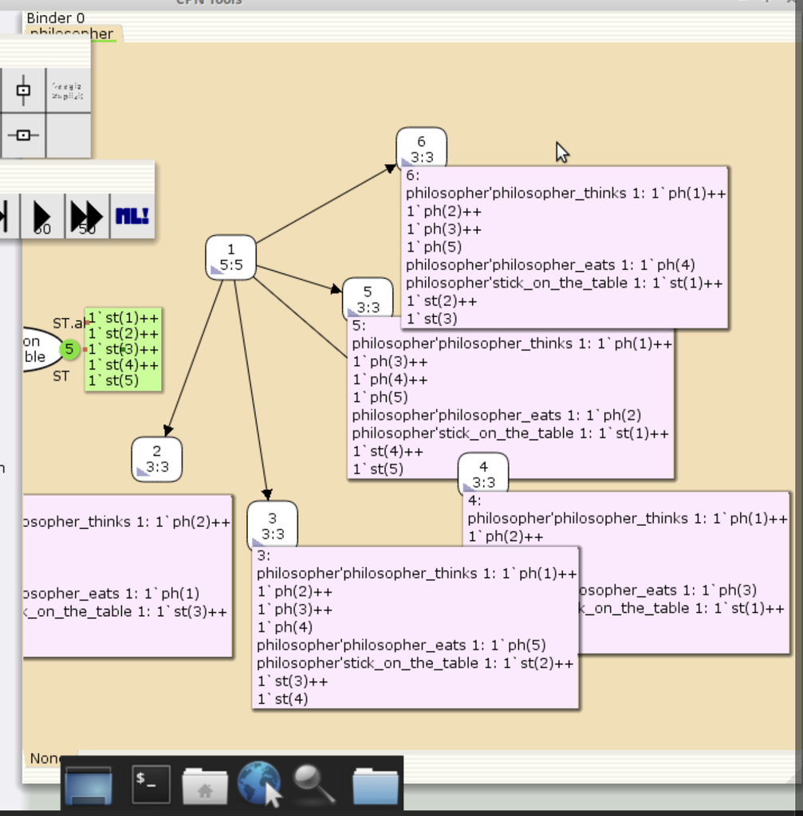

## А так же получаем отчет о пространстве состояний.

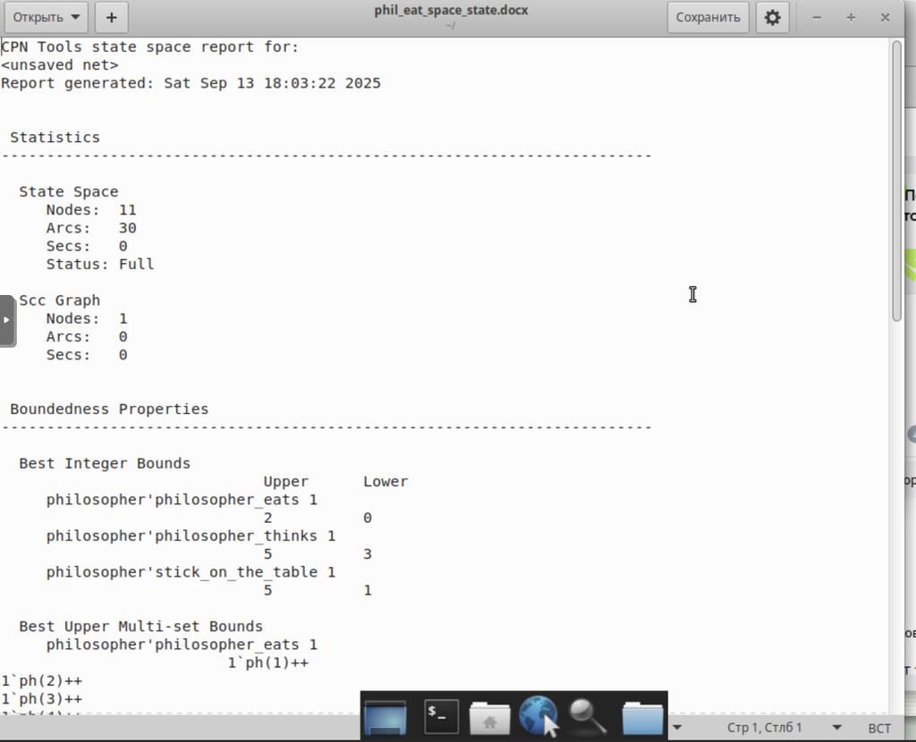

# Результаты

Мы ознакомились с моделью “Задача об обедающих мудрецах”. Ознакомились с базовыми аспектами работы в CPNTools.

Получили отчет по работе модели.